# Exercicio 5

Carolina Gabriela Dolléans 20/07/2020

## Carregue o banco de dados `world` que está no pacote `poliscidata`.

```r
library(poliscidata)

banco <- world
```

## Existem diversas medidas de democracia para os países: `dem_score14`, `democ11`, `fhrate04_rev`, `fhrate08_rev`, `polity`. Descreva-as graficamente e diga quais são as diferenças entre tais medidas.

```r
library(tidyverse)
```

**Gráficos dem_score14:**

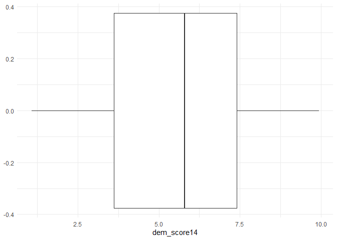

```r
ggplot(banco, aes(dem_score14)) +
  geom_boxplot() +
  theme_minimal()
```

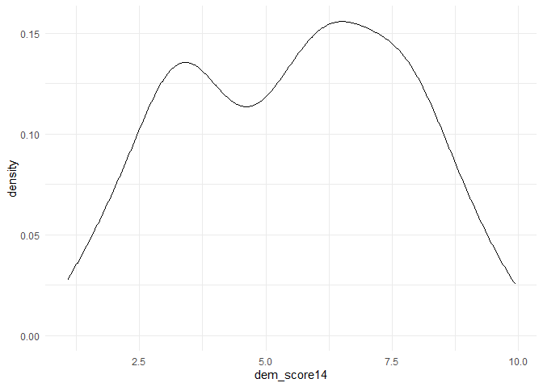

```r
ggplot(banco, aes(dem_score14)) +
  geom_density()+
  theme_minimal()
```

Esse gráfico em boxplot representa a variável dem_score14. É uma variável que mede o nível de democracia de cada país entre 0 e 10. Podemos ver com o gráfico de boxplot que os segundo e terceiro quartis têm a maior densidade de países. O segundo quartil tem valores entre 3.5 e 6 e o terceiro entre 6 e quase 7.5. Ou seja, a maoria dos países tem níveis médios de democracia.

Com o gráfico de densidade, a gente pode ver que há dois picos, um em mais ou menos 3.5 e outro maior em 6.5. Os países em 3.5 são provavelmente regimes autoritários e os regimes em 6.5 são provavelmente democracias.

**Gráficos de democ11:**

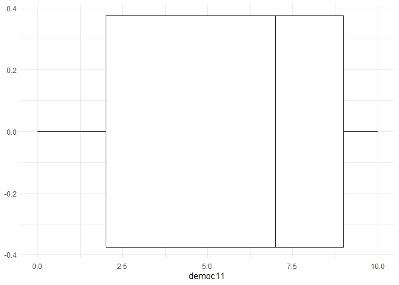

```r
ggplot(banco, aes(democ11)) +
  geom_boxplot()+
  theme_minimal()
```

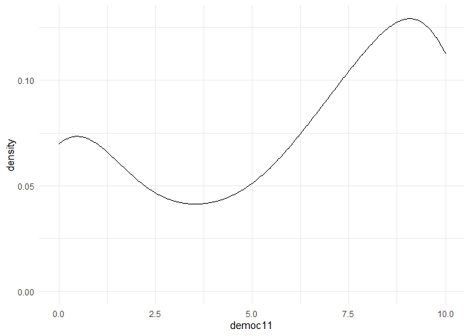

```r
ggplot(banco, aes(democ11)) +
  geom_density()+
  theme_minimal()
```

O gráfico em boxplot mostra que o terceiro (de quase 7 a quase 9) e o quarto (de quase 9 a 10) quartis são aqueles que contêm mais observações.Têm valores particularmente concentrados entre quase 7 e quase 9, o terceiro quartil.

O gráfico de densidade mostra que há dois picos, um menor em 0.5 e outro em quase 9. Podemos ver que há poucos valores médios.

Esse indício têm mais valores extremos. Interpretando, teria muitas democracias quase plenas e alguns regimes muito autoritários.

Ou seja, esse indício deve utilizar definições muito mínimas de regimes: ou é democracia ou é regime autoritário.

**Gráficos de fhrate04_rev:**

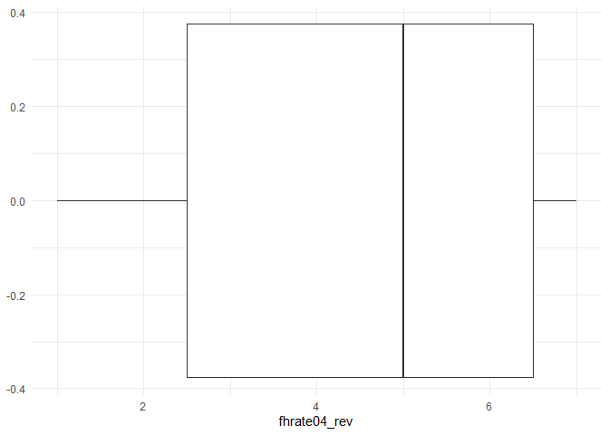

```r
ggplot(banco, aes(fhrate04_rev)) +
  geom_boxplot()+
  theme_minimal()
```

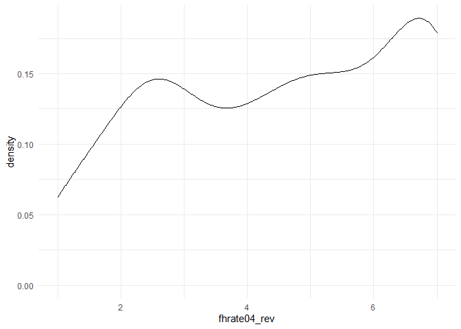

```r
ggplot(banco, aes(fhrate04_rev)) +
  geom_density()+
  theme_minimal()
```

Podemos ver que os terceiro e quarto quartis são os mais concetrados. Ou seja, visto que o indício é reverso, há mais democracias que regimes autoritários. O gráfico de densidade reforça essa primeira observação. Como outros gráficos precedentes (democ11), podemos ver dois picos, um menor (em 2.5) e um maior (em 6.5). Porém, esses picos não são separados por um abismo, a curva é quase sempre positiva entre os dois picos. Então, há muitos regimes ambíguos e muitas democracias.

**Gráficos de fhrate08_rev:**

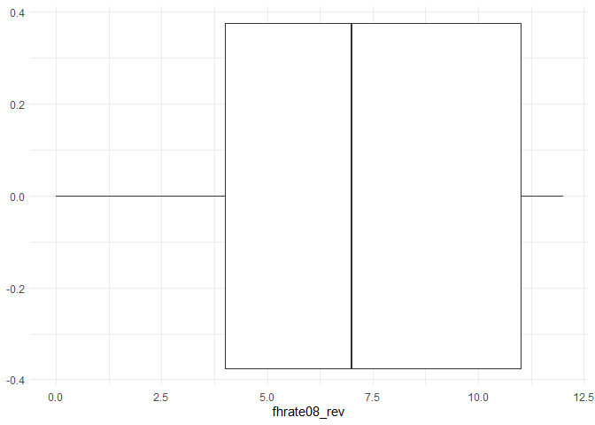

```r
ggplot(banco, aes(fhrate08_rev)) +
  geom_boxplot()+
  theme_minimal()
```

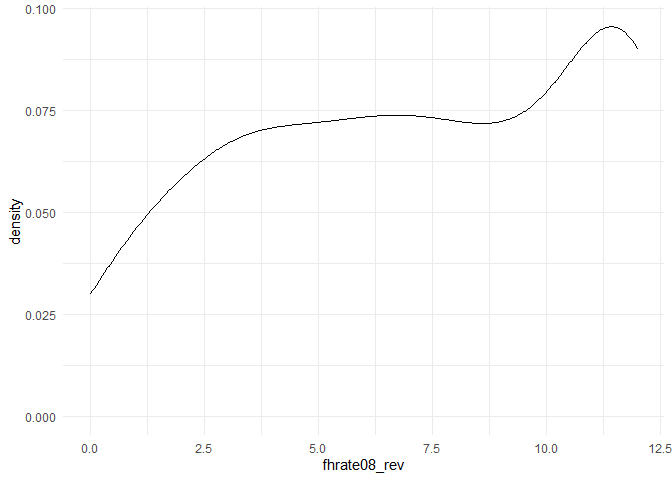

```r
ggplot(banco, aes(fhrate08_rev)) +
  geom_density()+
  theme_minimal()
```

Nesse gráfico de boxplot de fhrate08_rev, o segundo e o quarto quartis são os mais concentrados. Ou seja, há muitos valores médios e muitos valores altos. O gráfico de densidade mostra que o nível de democracia é constante de 3 até 8.5 e sobe até atingir um pico em 11. Ou seja, há muitos regimes ambíguos (entre 3 e 8.5) e muitas democracias.

Assumindo que 08 quer dizer 2008 e 04 2004, podemos observar uma evolução do número de democracias de 2004 a 2008.

**Gráficos de polity:**

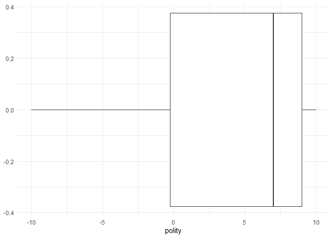

```r
ggplot(banco, aes(polity)) +
  geom_boxplot()+
  theme_minimal()
```

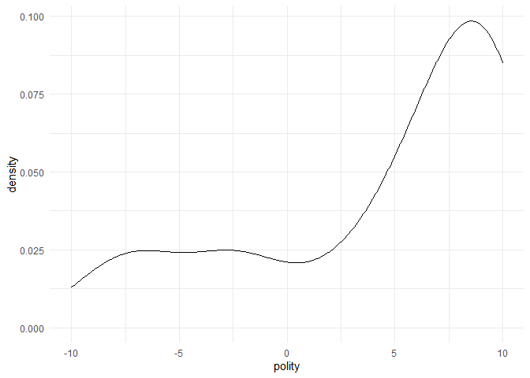

```r
ggplot(banco, aes(polity)) +
  geom_density()+
  theme_minimal()
```

Esse gráfico de boxplot de polity mostra que há muitos valores concentrados no terceiro e quarto quartil. O gráfico de densidade mostra que há um número baixo e quase constante de regimes entre - 10 e 0 e que o nível de democracia sobe até 8 onde atinge seu pico. Ou seja, tem muito mais democracias do que regimes autoritários e ambíguos.

Ou seja, esse indício deve ter uma definição mínima de democracia.

**Recapitulando**, a maioria desses gráficos mostram que há muitas democracias. Em função das definições das variáveis estudadas, tem mais ou menos regimes ambíguos e mais ou menos regimes autoritários. * Com uma quantidade significativa de regimes ambíguos: fhrate04_rev, fhrate08_rev. * Com uma quantidade significativa regimes autoritários: dem_score14, democ11. * Apenas com muitas democracias: polity.

## Avalie a relação entre todas as medidas de democracia e desigualdade, utilizando a variável `gini08`. Descreva graficamente esta variável, a relação entre as duas variáveis, meça a correlação entre elas e faça regressões lineares (interpretando em profundidade os resultados dos coeficientes e medidas de desempenho dos modelos). Enfatize as semelhanças e diferenças entre os resultados. Quais são suas conclusões?

**Gráficos do indício de Gini:**

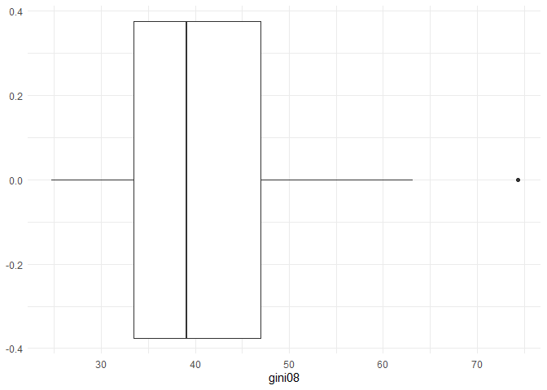

```r
ggplot(banco, aes(gini08)) +
  geom_boxplot()+
  theme_minimal()
```

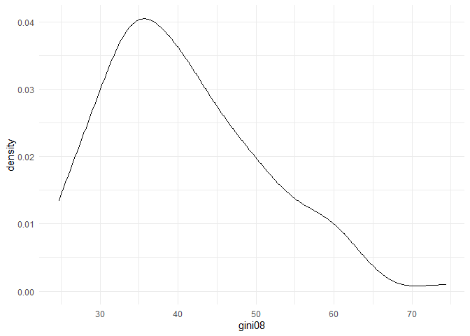

```r
ggplot(banco, aes(gini08)) +
  geom_density()+
  theme_minimal()
```

Podemos ver no gráfico de boxplot que a maioria dos países estão concentrados entre 33 e 47 no indício de Gini. O gráfico de densidade confirma isso: há um pico em 36. Ou seja, a maioria dos países têm um indício de Gini médio-fraco, abaixo de 50.

Para avaliar a relação entre o indício de Gini e as variáveis que medem a democracia, eu vou considerar que eu quero achar o nível de democracia a partir do indício de Gini. Ou seja, gini08 vai ser minha variável independente, x, e as variáveis que medem o nível de democracia serão minhas variáveis dependentes, y.

### Comparação entre gini08 e dem_score14

**Gráfico de gini08 em relação a dem_score14:**

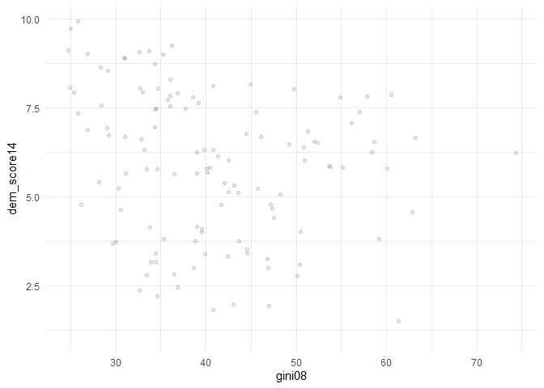

```r
ggplot(banco, aes(gini08, dem_score14)) +
  geom_point(alpha = 0.1)+
  theme_minimal()
```

Nesse gráfico, conseguimos destacar que, de maneira geral, países mais democráticos tem indícios de Gini mais fracos, ou seja, são menos desiguais. Além disso, países menos democráticos têm indícios de Gini mais altos, ou seja, são mais desiguais.

**Teste de correlação entre gini08 e dem_score14:**

```r
cor.test(banco$gini08, banco$dem_score14)
```

```
##
##  Pearson's product-moment correlation
##
## data:  banco$gini08 and banco$dem_score14
## t = -2.4621, df = 120, p-value = 0.01523
## alternative hypothesis: true correlation is not equal to 0
## 95 percent confidence interval:
##  -0.38215203 -0.04321115
## sample estimates:
##        cor
## -0.2192877
```

O coeficiente de correlação entre o indício de Gini e dem_score14 é fraco e negativo (-0.2192877). Esse resultado é confiável porque o p-valor é menor do que 0.05, tem valor de 0.01523. Apesar do intervalo de confiança ser pequeno, a correlação sendo fraca, não poderemos ter boas previsões com essa correlação. Porém, é o melhor modelo que temos nessa questão.

Esse teste de correlação confirma o gráfico.

**Regressão Linear entre gini08 e dem_score14:**

```r
regressao <- lm(dem_score14 ~ gini08, data = banco)
summary(regressao)
```

```
##
## Call:
## lm(formula = dem_score14 ~ gini08, data = banco)
##
## Residuals:
##     Min      1Q  Median      3Q     Max
## -4.0728 -1.7583  0.3513  1.6742  3.3600
##
## Coefficients:
##             Estimate Std. Error t value Pr(>|t|)
## (Intercept)  7.71756    0.75639  10.203   <2e-16 ***
## gini08      -0.04448    0.01807  -2.462   0.0152 *
## ---
## Signif. codes:  0 '***' 0.001 '**' 0.01 '*' 0.05 '.' 0.1 ' ' 1
##
## Residual standard error: 2.003 on 120 degrees of freedom
##   (45 observations deleted due to missingness)
## Multiple R-squared:  0.04809,    Adjusted R-squared:  0.04015
## F-statistic: 6.062 on 1 and 120 DF,  p-value: 0.01523
```

O estimate de gini08 nos indica que quando o indício de Gini sobe de um ponto, o nível de democracia (dem_score14) diminui de 0.04448, o que é pouco. O erro sobre esse valor é de 0.01807, ou seja quase a metade do estimate. Por essa razão, por que o erro é grande em relação ao estimate, o t não é muito grande -2.462. Enfim, esse estimate tem um p-valor bom de 0.0152, menor do que 0.05, o aue indica uma significância estatística.

O RMSE é grande: 2.003. Ou seja, se a gente fosse prever o nível de democracia de um país a partir do seu indício de Gini, esse modelo teria um erro médio de 2.003, o que é grande.

**Gráfico da regressão linear entre gini08 e dem_score14:**

```
## Warning: Removed 45 rows containing non-finite values (stat_smooth).

## Warning: Removed 45 rows containing missing values (geom_point).
```

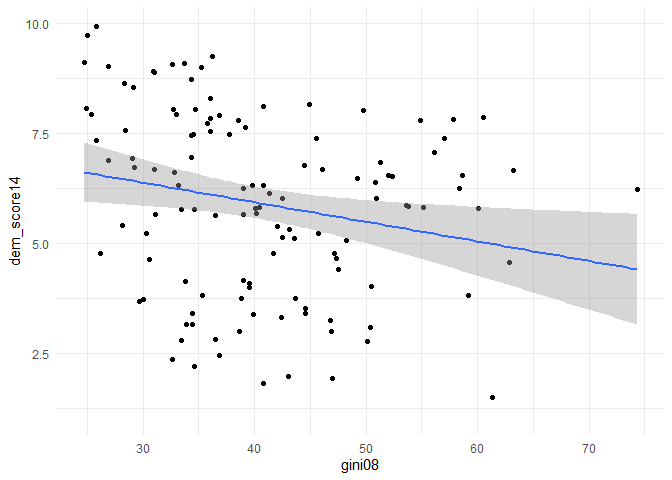

```r
ggplot(banco, aes(gini08, dem_score14)) +
  geom_point() +
  geom_smooth(method = "lm")+
  theme_minimal()
```

Nesse gráfico, podemos ver que a relação entre gini08 e dem_score14 é negativa e o declive é baixo. Podemos também observar que o erro é maior a medida que o valor de gini08 se distancia de mais ou menos 40. Talvez isso tenha a ver com o fato que mais o nível de gini08 aumenta, menos há observações.

### Comparação entre gini 08 e democ11

**Gráfico de gini08 em relação a democ11:**

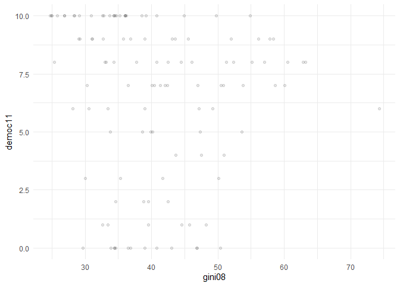

```r
ggplot(banco, aes(gini08, democ11)) +
  geom_point(alpha = 0.1)+
  theme_minimal()
```

Nesse gráfico, conseguimos destacar que, de maneira geral, países mais democráticos tem indícios de Gini mais fracos, ou seja, são menos desiguais, e que países menos democráticos têm indícios de Gini mais altos, ou seja, são mais desiguais. Porém, vemos que essa evolução negativa não fica tão clara nesse gráfico como no precedente porque muitos países são considerados democráticos (10) ou não democráticos (0) e têm indícios de Gini diversos.

**Teste de correlação entre gini 08 e democ11:**

```r
cor.test(banco$gini08, banco$democ11)
```

```
##
##  Pearson's product-moment correlation
##
## data:  banco$gini08 and banco$democ11
## t = -0.90439, df = 113, p-value = 0.3677
## alternative hypothesis: true correlation is not equal to 0
## 95 percent confidence interval:
##  -0.26378781  0.09988899
## sample estimates:
##         cor
## -0.08477203
```

O coeficiente de correlação entre o indício de Gini e democ11 é muito fraco e negativo (-0.08477203). Esse resultado não é confiável porque o p-value é maior do que 0.05, tem valor de 0.3677. Além disso, o intervalo de confiança contém zero. Com todos esses resultados, concluimos que essa correlação é péssima, não podemos fazer previsões com ela.

Esse teste de correlação confirma o gráfico.

**Regressão Linear entre gini 08 e democ11:**

```r
regressao <- lm(democ11 ~ gini08, data = banco)
summary(regressao)
```

```
##
## Call:
## lm(formula = democ11 ~ gini08, data = banco)
##
## Residuals:
##    Min     1Q Median     3Q    Max
## -6.796 -2.213  1.302  3.049  3.958
##
## Coefficients:
##             Estimate Std. Error t value Pr(>|t|)
## (Intercept)  7.68568    1.38306   5.557 1.85e-07 ***
## gini08      -0.02994    0.03311  -0.904    0.368
## ---
## Signif. codes:  0 '***' 0.001 '**' 0.01 '*' 0.05 '.' 0.1 ' ' 1
##
## Residual standard error: 3.47 on 113 degrees of freedom
##   (52 observations deleted due to missingness)
## Multiple R-squared:  0.007186,   Adjusted R-squared:  -0.0016
## F-statistic: 0.8179 on 1 and 113 DF,  p-value: 0.3677
```

O estimate de gini08 nos indica que quando o indício de Gini sobe de um ponto, o nível de democracia (democ11) diminui de 0.02994, o que é pouco. O erro sobre esse valor é de 0.03311, ou seja é maior do que o estimate. Por essa razão, por que o erro é grande em relação ao estimate, o t não é é pequeno -0.904. Enfim, esse estimate tem um p-valor ruim de 0.368, maior do que 0.05.

O RMSE é gigante: 3.47. Ou seja, se a gente fosse prever o nível de democracia de um país a partir do seu indício de Gini, esse modelo teria um erro médio de 3.47, o que é muito grande.

**Gráfico da regressão linear entre gini08 e democ11:**

```
## Warning: Removed 52 rows containing non-finite values (stat_smooth).

## Warning: Removed 52 rows containing missing values (geom_point).
```

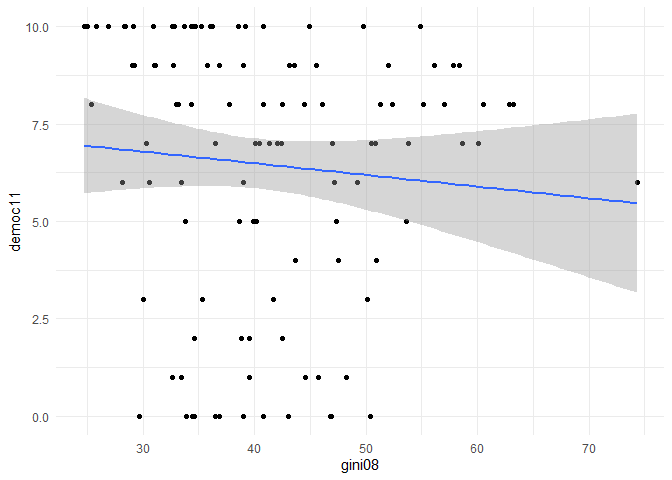

```r
ggplot(banco, aes(gini08, democ11)) +
  geom_point() +
  geom_smooth(method = "lm") +
  theme_minimal()
```

Nesse gráfico, podemos ver que a relação entre gini08 e democ11 é ligeiramente negativa e o declive é baixo. Podemos também observar que o erro, além de ser grande, é maior a medida que o valor de gini08 aumenta também. Talvez isso tenha a ver com o fato que mais o nível de gini08 aumenta, menos há observações.

### Comparação entre gini 08 e fhrate04_rev

**Gráfico de gini08 em relação a fhrate04_rev:**

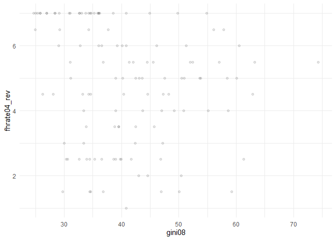

```r
ggplot(banco, aes(gini08, fhrate04_rev)) +
  geom_point(alpha = 0.1)+
  theme_minimal()
```

Nesse gráfico, conseguimos destacar que, de maneira geral, países mais democráticos tem indícios de Gini mais fracos, ou seja, são menos desiguais, e que países menos democráticos têm indícios de Gini mais altos, ou seja, são mais desiguais. Porém, vemos que essa evolução negativa não fica tão clara nesse gráfico como no precedente porque muitos países são considerados mais democráticos (7, 6, 5) ou menos democráticos (2-3) e têm indícios de Gini diversos.

**Teste de correlação entre gini 08 e fhrate04_rev:**

```r
cor.test(banco$gini08, banco$fhrate04_rev)
```

```
##
##  Pearson's product-moment correlation
##
## data:  banco$gini08 and banco$fhrate04_rev
## t = -1.9869, df = 120, p-value = 0.04921
## alternative hypothesis: true correlation is not equal to 0
## 95 percent confidence interval:
##  -0.3452745300 -0.0007294745
## sample estimates:
##        cor
## -0.1784673
```

O coeficiente de correlação entre o indício de Gini e fhrate04_rev é fraco e negativo (-0.1784673). Esse resultado é confiável porque o p-value é menor do que 0.05, tem valor de 0.04921. Porém, seu valor é muito próximo de 0.05, então, quase não é confiável. O intervalo de confiança é pequeno, mas a correlação é fraca, então não poderemos ter boas previsões com essa correlação.

Esse teste de correlação confirma o gráfico.

**Regressão Linear entre gini 08 e fhrate04_rev:**

```r
regressao <- lm(fhrate04_rev ~ gini08, data = banco)
summary(regressao)
```

```
##
## Call:
## lm(formula = fhrate04_rev ~ gini08, data = banco)
##
## Residuals:
##     Min      1Q  Median      3Q     Max
## -3.8312 -1.3896  0.4312  1.6729  2.6199
##
## Coefficients:
##             Estimate Std. Error t value Pr(>|t|)
## (Intercept)  6.13654    0.67419   9.102 2.35e-15 ***
## gini08      -0.03199    0.01610  -1.987   0.0492 *
## ---
## Signif. codes:  0 '***' 0.001 '**' 0.01 '*' 0.05 '.' 0.1 ' ' 1
##
## Residual standard error: 1.786 on 120 degrees of freedom
##   (45 observations deleted due to missingness)
## Multiple R-squared:  0.03185,    Adjusted R-squared:  0.02378
## F-statistic: 3.948 on 1 and 120 DF,  p-value: 0.04921
```

O RMSE é grande: 1.786. Ou seja, se a gente fosse prever o nível de democracia de um país a partir do seu indício de Gini, esse modelo teria um erro médio de 1.786, o que é grande.

**Gráfico da regressão linear entre gini08 e fhrate04_rev:**

```
## Warning: Removed 45 rows containing non-finite values (stat_smooth).

## Warning: Removed 45 rows containing missing values (geom_point).
```

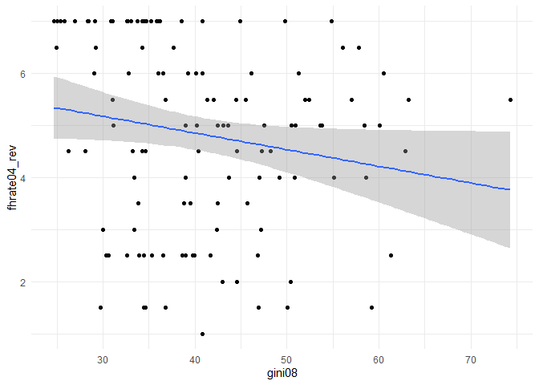

```r
ggplot(banco, aes(gini08, fhrate04_rev)) +
  geom_point() +
  geom_smooth(method = "lm") +
  theme_minimal()
```

Nesse gráfico, podemos ver que a relação entre gini08 e fhrate04_rev é ligeiramente negativa e o declive é baixo. Podemos também observar que o erro, além de ser grande, é maior a medida que o valor de gini08 aumenta também. Talvez isso tenha a ver com o fato que mais o nível de gini08 aumenta, menos há observações.

### Comparação entre gini e fhrate08_rev

**Gráfico de gini08 em relação a fhrate08_rev:**

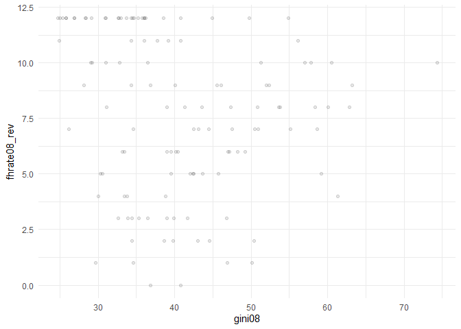

```r
ggplot(banco, aes(gini08, fhrate08_rev)) +
  geom_point(alpha = 0.1) +
  theme_minimal()
```

Nesse gráfico, conseguimos destacar que, de maneira geral, países mais democráticos tem indícios de Gini mais fracos, ou seja, são menos desiguais, e que países menos democráticos têm indícios de Gini mais altos, ou seja, são mais desiguais. Porém, vemos que essa evolução negativa não fica tão clara nesse gráfico, como no precedente, porque muitos países são considerados mais democráticos (8-12.5) ou menos democráticos (3-7) e têm indícios de Gini diversos.

**Teste de correlação entre gini 08 e fhrate08_rev:**

```r
cor.test(banco$gini08, banco$fhrate08_rev)
```

```
##
##  Pearson's product-moment correlation
##
## data:  banco$gini08 and banco$fhrate08_rev
## t = -1.7432, df = 119, p-value = 0.08387
## alternative hypothesis: true correlation is not equal to 0
## 95 percent confidence interval:
##  -0.32708386  0.02129614
## sample estimates:
##        cor
## -0.1578002
```

O coeficiente de correlação entre o indício de Gini e fhrate08_rev é muito fraco e negativo (-0.1578002). Esse resultado não é confiável porque o p-value é maior do que 0.05, tem valor de 0.08387 Além disso, o intervalo de confiança contém zero. Com todos esses resultados, concluimos que essa correlação é péssima, não podemos fazer previsões com ela.

Esse teste de correlação confirma o gráfico.

**Regressão Linear entre gini08 e fhrate08_rev:**

```r
regressao <- lm(fhrate08_rev ~ gini08, data = banco)
summary(regressao)
```

```
##
## Call:
## lm(formula = fhrate08_rev ~ gini08, data = banco)
##
## Residuals:
##     Min      1Q  Median      3Q     Max
## -7.9157 -2.5971  0.6712  3.4091  5.0961
##
## Coefficients:
##             Estimate Std. Error t value Pr(>|t|)
## (Intercept)  9.97288    1.34188   7.432 1.79e-11 ***
## gini08      -0.05590    0.03207  -1.743   0.0839 .
## ---
## Signif. codes:  0 '***' 0.001 '**' 0.01 '*' 0.05 '.' 0.1 ' ' 1
##
## Residual standard error: 3.554 on 119 degrees of freedom
##   (46 observations deleted due to missingness)
## Multiple R-squared:  0.0249, Adjusted R-squared:  0.01671
## F-statistic: 3.039 on 1 and 119 DF,  p-value: 0.08387
```

O estimate de gini08 nos indica que quando o indício de Gini sobe de um ponto, o nível de democracia (fhrate08_rev) diminui de 0.05590, o que é pouco. O erro sobre esse valor é de 0.03207, ou seja é mais da metade do estimate. Por essa razão, por que o erro é grande em relação ao estimate, o t é pequeno -1.743. Enfim, esse estimate tem um p-valor de 0.0839, maior do que 0.05.

O RMSE é gigante: 3.554. Ou seja, se a gente fosse prever o nível de democracia de um país a partir do seu indício de Gini, esse modelo teria um erro médio de 3.554, o que é gigante.

**Gráfico da regressão linear entre gini08 e fhrate08_rev:**

```
## Warning: Removed 46 rows containing non-finite values (stat_smooth).

## Warning: Removed 46 rows containing missing values (geom_point).
```

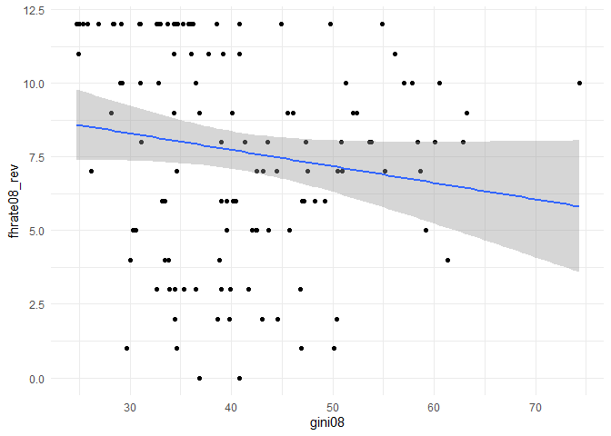

```r
ggplot(banco, aes(gini08, fhrate08_rev)) +
  geom_point() +
  geom_smooth(method = "lm") +
  theme_minimal()
```

Nesse gráfico, podemos ver que a relação entre gini08 e fhrate08_rev é negativa e o declive é baixo. Podemos também observar que o erro, além de ser grande, é maior a medida que o valor de gini08 aumenta também. Talvez isso tenha a ver com o fato que mais o nível de gini08 aumenta, menos há observações.

### Comparação entre gini 08 e polity

**Gráfico de gini08 em relação a polity:**

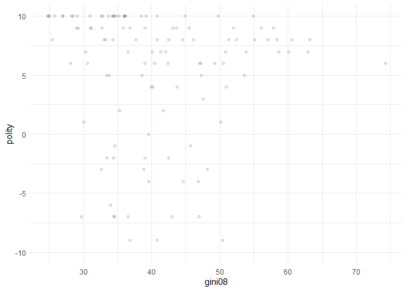

```r
ggplot(banco, aes(gini08, polity)) +
  geom_point(alpha = 0.1) +
  theme_minimal()
```

Esse gráfico não mostra nenhum padrão evidente. Assim, há muitas democracias com valores muito diferentes do indício de Gini.

**Teste de correlação entre gini 08 e polity:**

```r
cor.test(banco$gini08, banco$polity)
```

```
##
##  Pearson's product-moment correlation
##
## data:  banco$gini08 and banco$polity
## t = -0.43417, df = 113, p-value = 0.665
## alternative hypothesis: true correlation is not equal to 0
## 95 percent confidence interval:
##  -0.2222590  0.1433725
## sample estimates:
##         cor
## -0.04080936
```

Esse teste de correlação confirma o gráfico.

**Regressão Linear entre gini08 e polity:**

```r
regressao <- lm(polity ~ gini08, data = banco)
summary(regressao)
```

```
##
## Call:
## lm(formula = polity ~ gini08, data = banco)
##
## Residuals:
##     Min      1Q  Median      3Q     Max
## -14.374  -1.300   2.364   4.087   5.040
##
## Coefficients:
##             Estimate Std. Error t value Pr(>|t|)
## (Intercept)  6.21813    2.20594   2.819  0.00569 **
## gini08      -0.02292    0.05280  -0.434  0.66499
## ---
## Signif. codes:  0 '***' 0.001 '**' 0.01 '*' 0.05 '.' 0.1 ' ' 1
##
## Residual standard error: 5.535 on 113 degrees of freedom
##   (52 observations deleted due to missingness)
## Multiple R-squared:  0.001665,   Adjusted R-squared:  -0.007169
## F-statistic: 0.1885 on 1 and 113 DF,  p-value: 0.665
```

O estimate de gini08 nos indica que quando o indício de Gini sobe de um ponto, o nível de democracia (polity) diminui de 0.02292, o que é muito pouco. O erro sobre esse valor é de 0.05280, ou seja é maior do que o estimate. Por essa razão, por que o erro é grande em relação ao estimate, o t é muito pequeno -0.434. Enfim, esse estimate tem um p-valor de 0.66499, maior do que 0.05.

O RMSE é gigante: 5.535. Ou seja, se a gente fosse prever o nível de democracia de um país a partir do seu indício de Gini, esse modelo teria um erro médio de 5.535, o que é gigante.

Essa foi, sem dúvida, a pior regressão. Da mesma forma, foi o pior teste de correlação foi entre gini08 e polity.

**Gráfico da regressão linear entre gini08 e polity:**

```
## Warning: Removed 52 rows containing non-finite values (stat_smooth).

## Warning: Removed 52 rows containing missing values (geom_point).
```

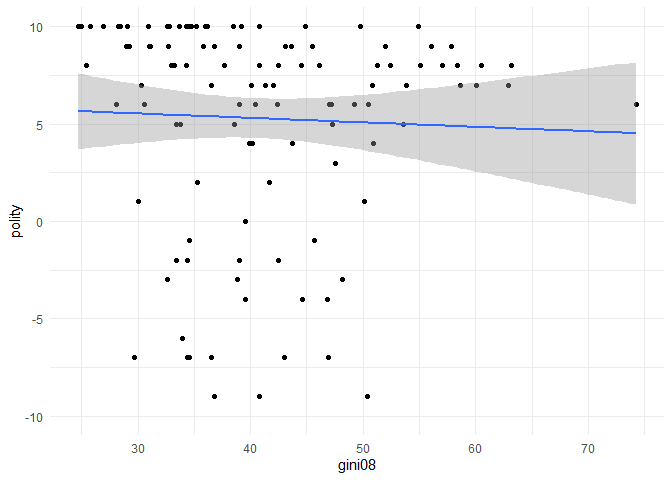

```r
ggplot(banco, aes(gini08, polity)) +
  geom_point() +
  geom_smooth(method = "lm") +
  theme_minimal()
```

### Comparação entre os testes de correlação:

Podemos ver que nenhum teste de correlação deu certo. Assim, o “melhor” teste de correlação é o primeiro com a variável dem_score14 (-0.2192877), que, ainda é fraco. O outro teste de correlação indicou alguma relação, mesmo se fraca, foi com a variável fhrate04_rev (-0.1784673). Todos os outros (democ11, fhrate08_rev, polity) deram resultados que indicam que não há relaçao entre o indício de Gini e o nível de democracia. Ou seja, a diferença de renda nao permite fazer previsões sobre o nível de democracia. Uma informação relevante que podemos aprender desses testes é que, se existe uma relação entre o indício de Gini e o nível de democracia, essa relação é negativa: quando o indício de Gini aumenta, o nível de democracia baixa.

### Comparação entre as regressões:

Da mesma forma que com os testes de correlação, as regressões lineares não foram muito conclusivas. Assim, os melhores modelos, que têm alguma significância estatística, são aqueles com as variáveis fhrate04_rev (no limite) e dem_score14. Porém, mesmo assim, não parecem ser bons modelos. Os outros, com democ11, fhrate08_rev e polity, tiveram p-valores altos demais para considerá-los significativos.

## Avalie a relação entre todas as medidas de democracia e crescimento econômico, utilizando a variável `gdppcap08`. Descreva graficamente esta variável, a relação entre as duas variáveis, meça a correlação entre elas e faça regressões lineares (interpretando em profundidade os resultados dos coeficientes e medidas de desempenho dos modelos). Enfatize as semelhanças e diferenças entre os resultados. Quais são suas conclusões?

**Gráfico da variável gdppcap08:**

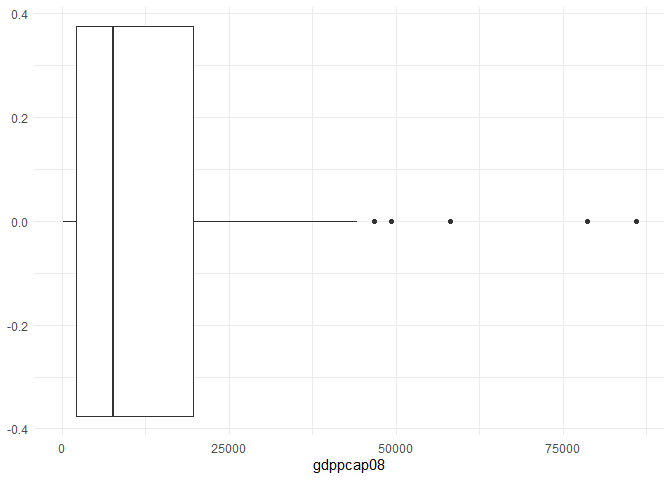

```r
ggplot(banco, aes(gdppcap08)) +
  geom_boxplot() +
  theme_minimal()
```

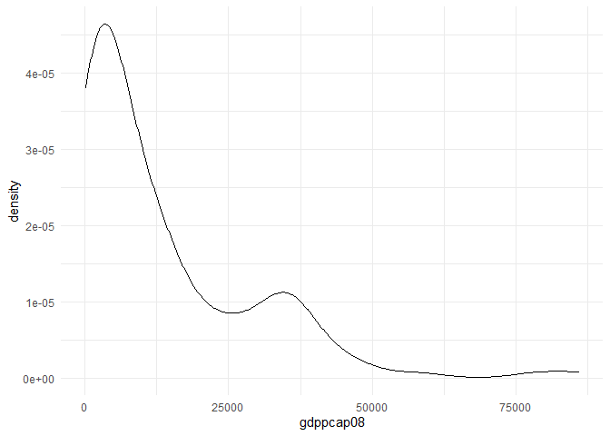

```r
ggplot(banco, aes(gdppcap08)) +
  geom_density() +
  theme_minimal()
```

No gráfico de boxplot, podemos ver que os valores de PIB per capita dos países são concentrados no início dos valores do PIB per capita (antes de mais ou menos 20 000). Os dois primeiros quartis são os mais densos. No gráfico de densidade, há um pico em menos de 10 000 e outro bem menor em 30 000.

### Comparação entre gdppcap08 08 e dem_score14

**Gráfico de gdppcap08 em relação a dem_score14:**

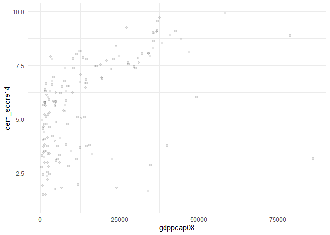

```r
ggplot(banco, aes(gdppcap08, dem_score14)) +
  geom_point(alpha = 0.1) +
  theme_minimal()
```

Nesse gráfico, conseguimos claramente ver uma evolução no sentido de “países poucos democráticos com PIB per capita fraco” para “países mais democráticos com PIB per capita maior”.

**Teste de correlação entre gdppcap08 e dem_score14:**

```r
cor.test(banco$gdppcap08, banco$dem_score14)
```

```
##
##  Pearson's product-moment correlation
##
## data:  banco$gdppcap08 and banco$dem_score14
## t = 7.1713, df = 150, p-value = 3.159e-11
## alternative hypothesis: true correlation is not equal to 0
## 95 percent confidence interval:
##  0.3763618 0.6150148
## sample estimates:
##       cor
## 0.5052872
```

O coeficiente de correlação entre as variáveis gdppcap08 e dem_score14 é médio e positivo (0.5052872). Ou seja, quando o PIB per capita aumenta, o nível de democracia também aumenta. Esse resultado é confiável porque o p-value é menor do que 0.05, aliás, é muito pequeno, tem um valor de 3.159e-11 O intervalo de confiança sendo pequeno (menos de 0.3) e a correlação média, poderemos ter relativamente boas previsões com essa correlação. Ou seja, poderemos estimar o nível de democracia de um país a partir do PIB per capita com uma precisão correta.

Esse teste de correlação confirma o gráfico.

**Regressão Linear entre gdppcap08 e dem_score14:**

```r
regressao <- lm(dem_score14 ~ gdppcap08, data = banco)
summary(regressao)
```

```
##
## Call:
## lm(formula = dem_score14 ~ gdppcap08, data = banco)
##
## Residuals:
##     Min      1Q  Median      3Q     Max
## -7.5428 -1.3420  0.6982  1.2843  3.0329
##
## Coefficients:
##              Estimate Std. Error t value Pr(>|t|)
## (Intercept) 4.678e+00  2.017e-01  23.197  < 2e-16 ***
## gdppcap08   7.040e-05  9.817e-06   7.171 3.16e-11 ***
## ---
## Signif. codes:  0 '***' 0.001 '**' 0.01 '*' 0.05 '.' 0.1 ' ' 1
##
## Residual standard error: 1.864 on 150 degrees of freedom
##   (15 observations deleted due to missingness)
## Multiple R-squared:  0.2553, Adjusted R-squared:  0.2504
## F-statistic: 51.43 on 1 and 150 DF,  p-value: 3.159e-11
```

O estimate de gdppcap08 nos indica que quando o PIB per capita sobe de um ponto, o nível de democracia (dem_score14) aumenta de 7.040e-05, o que é igual a 7.04*10^(-5). Esse valor parece ser pequeno, mas para entendê-lo, precisamos olhar para os valores de gdppcap08. Assim, gdppcap08 pega valores de 188 (Zimbabwe) até 85868 (Quatar). Então, uma variação de 1000, por exemplo, daria uma variação no nível de democracia de 7.04e-02 = 0.0704. Uma variação de 10 000 da um aumento de 0.704 no nível de democracia.

O erro sobre esse valor é de 9.817e-06, ou seja, é menor do que o estimate. Para um aumento de 1000 do PIB per capita, o erro é de 9.817e-03, o que é pouco em relação a 7.04e-2. Por essa razão, o t parece ser razoavelmente grande: 7.171. Enfim, esse estimate tem um p-valor de 3.16e-11, muito menor do que 0.05, então o modelo é estatisticamente significativo.

O RMSE é grande: 1.864. Ou seja, se a gente fosse prever o nível de democracia de um país a partir do seu PIB per capita, esse modelo teria um erro médio de 1.864, o que muito é grande, sobretudo visto que o estimate é tão pequeno.

Enfim, o Multiple R-squared é grande: 0.2553, ou seja mais de 25%. Isso significa que a variação do nível de democracia é em parte explicada pela variação no PIB per capita.

Esse modelo de regressão é um bom modelo. O melhor?

**Gráfico da regressão linear entre gdppcap08 e dem_score14:**

```
## Warning: Removed 15 rows containing non-finite values (stat_smooth).

## Warning: Removed 15 rows containing missing values (geom_point).
```

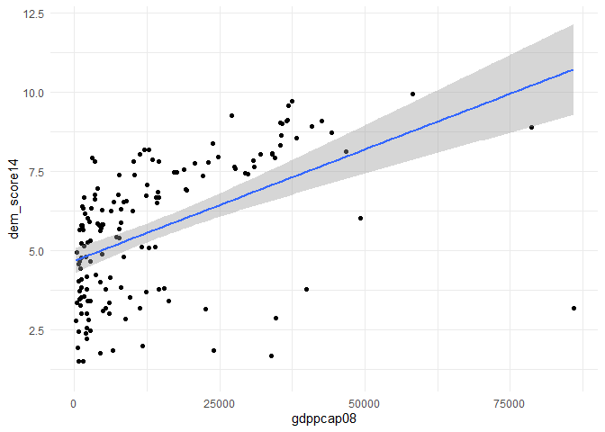

```r
ggplot(banco, aes(gdppcap08, dem_score14)) +
  geom_point() +
  geom_smooth(method = "lm") +
  theme_minimal()
```

Podemos ver, nesse gráfico, que a relação entre gdppcap08 e dem_score14 é positiva. Da mesma forma que com gini08, o erro aumenta a medida que gdppcap08 aumenta, provavelmente por falta de observações.

### Comparação entre gdppcap08 08 e democ11

**Gráfico de gdppcap08 em relação a democ11:**

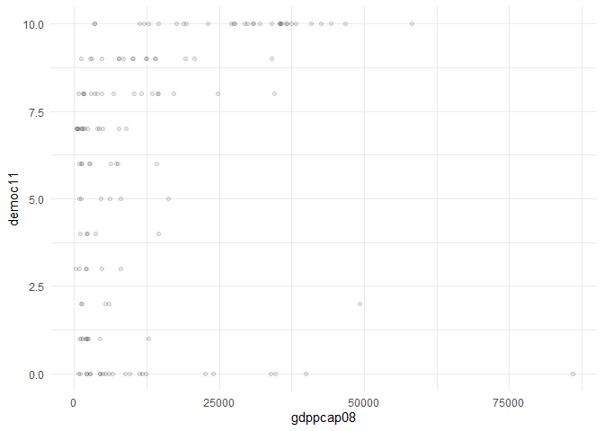

```r
ggplot(banco, aes(gdppcap08, democ11)) +
  geom_point(alpha = 0.1) +
  theme_minimal()
```

Nesse gráfico, conseguimos ver uma evolução fraca no sentido de “países poucos democráticos com PIB per capita fraco” para “países mais democráticos com PIB per capita maior”.Porém, essa evolução não ficou muito clara porque há muitos países muito democráticos (com 10, ou perto de 10) e muitos países absolutamente não democráticos (com 0, ou perto de 0).

**Teste de correlação entre gdppcap08 e democ11:**

```r
cor.test(banco$gdppcap08, banco$democ11)
```

```
##
##  Pearson's product-moment correlation
##
## data:  banco$gdppcap08 and banco$democ11
## t = 3.6037, df = 140, p-value = 0.000435
## alternative hypothesis: true correlation is not equal to 0
## 95 percent confidence interval:
##  0.1330147 0.4351981
## sample estimates:
##      cor
## 0.291358
```

O coeficiente de correlação entre as variáveis gdppcap08 e democ11 é fraco e positivo (0.291358). Ou seja, quando o PIB per capita aumenta, o nível de democracia aumenta um pouco. Esse resultado é confiável porque o p-valor é menor do que 0.05, tem um valor de 0.000435. O intervalo de confiança sendo pequeno (mais ou menos 0.3) e a correlação fraca, nao poderemos ter boas previsões com essa correlação. Ou seja, não poderemos estimar o nível de democracia de um país a partir do PIB per capita com muita precisão.

Esse teste de correlação confirma o gráfico.

**Regressão Linear entre gdppcap08 e democ11:**

```r
regressao <- lm(democ11 ~ gdppcap08, data = banco)
summary(regressao)
```

```
##
## Call:
## lm(formula = democ11 ~ gdppcap08, data = banco)
##
## Residuals:
##     Min      1Q  Median      3Q     Max
## -11.258  -3.030   1.723   2.783   4.803
##
## Coefficients:
##              Estimate Std. Error t value Pr(>|t|)
## (Intercept) 4.939e+00  4.026e-01  12.270  < 2e-16 ***
## gdppcap08   7.359e-05  2.042e-05   3.604 0.000435 ***
## ---
## Signif. codes:  0 '***' 0.001 '**' 0.01 '*' 0.05 '.' 0.1 ' ' 1
##
## Residual standard error: 3.57 on 140 degrees of freedom
##   (25 observations deleted due to missingness)
## Multiple R-squared:  0.08489,    Adjusted R-squared:  0.07835
## F-statistic: 12.99 on 1 and 140 DF,  p-value: 0.000435
```

O estimate de gdppcap08 nos indica que quando o PIB per capita sobe de um ponto, o nível de democracia (democ11) aumenta de 7.359e-05. Esse valor parece ser pequeno, mas, pelas mesmas razões do que na regressão anterior, é um valor grande.

O RMSE é grande: 3.57. Ou seja, se a gente fosse prever o nível de democracia de um país a partir do seu PIB per capita, esse modelo teria um erro médio de 3.57, o que é grande.

Enfim, o Multiple R-squared é muito baixo: 0.08489, menos de 9%. Isso significa que a variação do nível de democracia é pouco explicada pela variação no PIB per capita.

Feito a correlação, esse modelo de regressão linear é significativo, mas não permite fazer boas previsões.

**Gráfico da regressão linear entre gdppcap08 e democ11:**

```
## Warning: Removed 25 rows containing non-finite values (stat_smooth).

## Warning: Removed 25 rows containing missing values (geom_point).
```

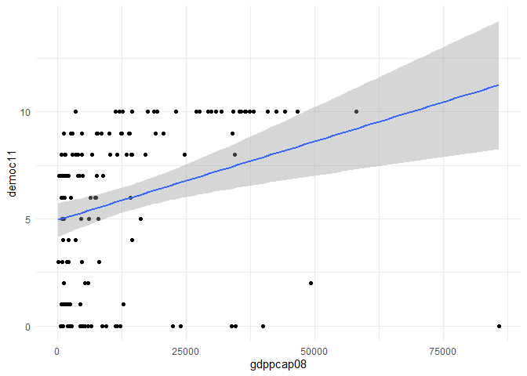

```r
ggplot(banco, aes(gdppcap08, democ11)) +
  geom_point() +
  geom_smooth(method = "lm") +
  theme_minimal()
```

Podemos ver, nesse gráfico, que a relação entre gdppcap08 e democ11 é positiva. Da mesma forma que anteriormente, o erro aumenta a medida que gdppcap08 aumenta, provavelmente por falta de observações.

### Comparação entre gdppcap08 08 e fhrate04_rev

**Gráfico de gdppcap08 em relação a fhrate04_rev:**

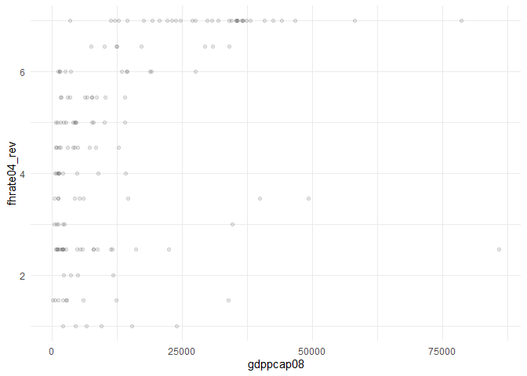

```r
ggplot(banco, aes(gdppcap08, fhrate04_rev)) +
  geom_point(alpha = 0.1) +
  theme_minimal()
```

Nesse gráfico, conseguimos ver uma evolução no sentido de “países poucos democráticos com PIB per capita fraco” para “países mais democráticos com PIB per capita maior”.

**Teste de correlação entre gdppcap08 e fhrate04_rev:**

```r
cor.test(banco$gdppcap08, banco$fhrate04_rev)
```

```
##
##  Pearson's product-moment correlation
##
## data:  banco$gdppcap08 and banco$fhrate04_rev
## t = 6.0129, df = 150, p-value = 1.331e-08
## alternative hypothesis: true correlation is not equal to 0
## 95 percent confidence interval:
##  0.3027442 0.5605748
## sample estimates:
##       cor
## 0.4407043
```

O coeficiente de correlação entre as variáveis gdppcap08 e fhrate04_rev é médio e positivo (0.4407043). Ou seja, quando o PIB per capita aumenta, o nível de democracia também aumenta. Esse resultado é confiável porque o p-valor é menor do que 0.05, aliás, é muito pequeno, tem um valor de 1.331e-08. O intervalo de confiança sendo pequeno (menos de 0.3) e a correlação média, concluimos que poderemos ter relativamente boas previsões com essa correlação. Ou seja, poderemos estimar o nível de democracia de um país a partir do PIB per capita com uma precisão correta.

Esse teste de correlação confirma o gráfico.

**Regressão Linear entre gdppcap08 e fhrate04_rev:**

```r
regressao <- lm(fhrate04_rev ~ gdppcap08, data = banco)
summary(regressao)
```

```
##
## Call:
## lm(formula = fhrate04_rev ~ gdppcap08, data = banco)
##
## Residuals:
##     Min      1Q  Median      3Q     Max
## -6.0897 -1.4154  0.5914  1.2481  2.9773
##
## Coefficients:
##              Estimate Std. Error t value Pr(>|t|)
## (Intercept) 3.828e+00  1.894e-01  20.210  < 2e-16 ***
## gdppcap08   5.545e-05  9.222e-06   6.013 1.33e-08 ***
## ---
## Signif. codes:  0 '***' 0.001 '**' 0.01 '*' 0.05 '.' 0.1 ' ' 1
##
## Residual standard error: 1.751 on 150 degrees of freedom
##   (15 observations deleted due to missingness)
## Multiple R-squared:  0.1942, Adjusted R-squared:  0.1888
## F-statistic: 36.16 on 1 and 150 DF,  p-value: 1.331e-08
```

O estimate de gdppcap08 nos indica que quando o PIB per capita sobe de um ponto, o nível de democracia (fhrate04_rev) aumenta de 5.545e-05. Esse valor parece ser pequeno, mas, pelas mesmas razões do que nas regressões anterior, é um valor grande.

O erro sobre esse valor é de 9.222e-06, ou seja é pequeno en relação ao estimate. Por essa razão o t vale 6.013. Enfim, esse estimate tem um p-valor de 1.33e-08, muito menor do que 0.05, então indicando uma significância estatística.

O RMSE é grande: 1.751. Ou seja, se a gente fosse prever o nível de democracia de um país a partir do seu PIB per capita, esse modelo teria um erro médio de 1.751, o que é grande.

Enfim, o Multiple R-squared é significativo: 0.1942, ou seja, quase 20%. Isso significa que a variação do nível de democracia é em parte explicada pela variação no PIB per capita.

**Gráfico da regressão linear entre gdppcap08 e fhrate04_rev:**

```
## Warning: Removed 15 rows containing non-finite values (stat_smooth).

## Warning: Removed 15 rows containing missing values (geom_point).
```

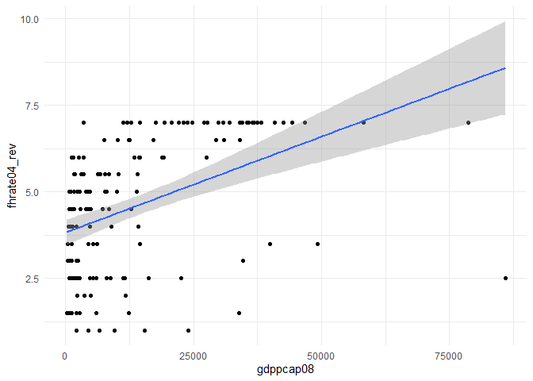

```r
ggplot(banco, aes(gdppcap08, fhrate04_rev)) +
  geom_point() +
  geom_smooth(method = "lm") +
  theme_minimal()
```

Podemos ver, nesse gráfico, que a relação entre gdppcap08 e fhrate04_rev é positiva. Da mesma forma que anteriormente, o erro aumenta a medida que gdppcap08 aumenta, provavelmente por falta de observações.

### Comparação entre gdppcap08 08 e fhrate08_rev

**Gráfico de gdppcap08 em relação a fhrate08_rev:**

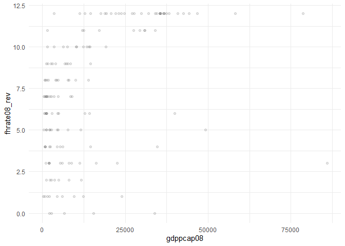

```r
ggplot(banco, aes(gdppcap08, fhrate08_rev)) +
  geom_point(alpha = 0.1) +
  theme_minimal()
```

Nesse gráfico, conseguimos ver uma evolução no sentido de “países poucos democráticos com PIB per capita fraco” para “países mais democráticos com PIB per capita maior”.

**Teste de correlação entre gdppcap08 e fhrate08_rev:**

```r
cor.test(banco$gdppcap08, banco$fhrate08_rev)
```

```
##
##  Pearson's product-moment correlation
##
## data:  banco$gdppcap08 and banco$fhrate08_rev
## t = 6.0508, df = 149, p-value = 1.115e-08
## alternative hypothesis: true correlation is not equal to 0
## 95 percent confidence interval:
##  0.3061176 0.5638582
## sample estimates:
##     cor
## 0.44413
```

O coeficiente de correlação entre as variáveis gdppcap08 e fhrate08_rev é médio e positivo (0.44413). Ou seja, quando o PIB per capita aumenta, o nível de democracia também aumenta. Esse resultado é confiável porque o p-value é menor do que 0.05, aliás, é muito pequeno, tem um valor de 1.115e-08. O intervalo de confiança sendo pequeno (menos de 0.3) e a correlação média, concluimos que poderemos ter relativamente boas previsões com esse modelo. Ou seja, poderemos estimar o nível de democracia de um país a partir do PIB per capita com uma precisão correta.

Esse teste de correlação confirma o gráfico.

Esse teste de correlação entre as variáveis gdppcap08 e fhrate08_rev deu melhores resultados do que o teste de correlação entre as variáveis gdppcap08 e fhrate04_rev.

**Regressão Linear entre gdppcap08 e fhrate08_rev:**

```r
regressao <- lm(fhrate08_rev ~ gdppcap08, data = banco)
summary(regressao)
```

```
##
## Call:
## lm(formula = fhrate08_rev ~ gdppcap08, data = banco)
##
## Residuals:
##     Min      1Q  Median      3Q     Max
## -12.124  -2.345   1.164   2.510   5.918
##
## Coefficients:
##              Estimate Std. Error t value Pr(>|t|)
## (Intercept) 5.698e+00  3.739e-01  15.237  < 2e-16 ***
## gdppcap08   1.098e-04  1.814e-05   6.051 1.11e-08 ***
## ---
## Signif. codes:  0 '***' 0.001 '**' 0.01 '*' 0.05 '.' 0.1 ' ' 1
##
## Residual standard error: 3.438 on 149 degrees of freedom
##   (16 observations deleted due to missingness)
## Multiple R-squared:  0.1973, Adjusted R-squared:  0.1919
## F-statistic: 36.61 on 1 and 149 DF,  p-value: 1.115e-08
```

O estimate de gdppcap08 nos indica que quando o PIB per capita sobe de um ponto, o nível de democracia (fhrate08_rev) aumenta de 1.098e-04. Esse valor parece ser pequeno, mas, pelas mesmas razões do que nas regressões anterior, é um valor grande.

O erro sobre esse valor é de 1.814e-05, ou seja é pequeno en relação ao estimate. Por essa razão o t vale 6.051. Enfim, esse estimate tem um p-valor de 1.11e-08, muito menor do que 0.05, então indicando uma significância estatística.

O RMSE é grande: 3.438. Ou seja, se a gente fosse prever o nível de democracia de um país a partir do seu PIB per capita, esse modelo teria um erro médio de 3.438, o que é grande.

Enfim, o Multiple R-squared é significante: 0.1973, ou seja, quase 20%. Isso significa que a variação do nível de democracia é em parte explicada pela variação no PIB per capita.

**Gráfico da regressão linear entre gdppcap08 e fhrate08_rev:**

```
## Warning: Removed 16 rows containing non-finite values (stat_smooth).

## Warning: Removed 16 rows containing missing values (geom_point).
```

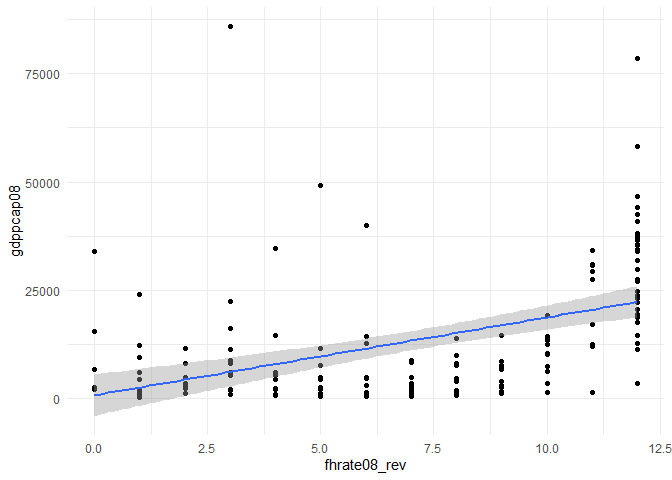

```r
ggplot(banco, aes(fhrate08_rev, gdppcap08)) +
  geom_point() +
  geom_smooth(method = "lm") +
  theme_minimal()
```

Os resultados dessa regressão são parecidos com a anterior porque as variáveis fhrate08_rev e fhrate04_rev são muito parecidas.